# rockfish spp id summary

I’m trying to summarize some of the species id work that Hayley Nuetzel did as I prep for writing the manuscript.

Here, I have the label.txt files for all of the samples included in the “final” combined VCF file. I will summarize the number of samples per species included.

```r
setwd("~/Desktop/sebastes_sppID/gtseq_seb_spp_id/label_files")
```

```
The working directory was changed to /Users/dianabaetscher/Desktop/sebastes_sppID/gtseq_seb_spp_id/label_files inside a notebook chunk. The working directory will be reset when the chunk is finished running. Use the knitr root.dir option in the setup chunk to change the working directory for noteboo…
```

```r
labels <- lapply(1:nrow(list), function(i) {
  read_tsv(list$file[i], col_names = FALSE)
}) %>%
  bind_rows()
vcf_samples <- labels %>%
  rename(file = X1, sample = X2, species = X3)
vcf_samples %>%
  group_by(species) %>%
  tally()
```

| species | n |
| --- | --- |
| babcocki | 15 |
| dalli | 15 |
| levis | 16 |
| reedi | 8 |
| Salutus | 24 |
| Satrovirens | 242 |
| Sauriculatus | 16 |
| Saurora | 16 |
| Sbabcocki | 1 |
| Scarnatus | 29 |

[output cut: 42 more lines]

| sample_type | repunit | collection | indiv | Plate_1_A01_Sat_GW603857_consensus.1 | Plate_1_A01_Sat_GW603857_consensus.2 | Plate_1_A11_Sat_GE820299_consensus.1 | Plate_1_A11_Sat_GE820299_consensus.2 | Plate_2_A09_Sat_EW986980_consensus.1 | Plate_2_A09_Sat_EW986980_consensus.2 | Plate_2_C08_Sat_EW987116_consensus.1 | Plate_2_C08_Sat_EW987116_consensus.2 | Plate_2_G06_Sat_EW987118_consensus.1 | Plate_2_G06_Sat_EW987118_consensus.2 | Plate_3_C03_Sat_GE798118_consensus.1 | Plate_3_C03_Sat_GE798118_consensus.2 | Plate_4_E10_Sat_EW976030_consensus.1 | Plate_4_E10_Sat_EW976030_consensus.2 | Plate_4_G06_Sat_EW976181_consensus.1 | Plate_4_G06_Sat_EW976181_consensus.2 | tag_id_1049.1 | tag_id_1049.2 | tag_id_108.1 | tag_id_108.2 | tag_id_1184.1 | tag_id_1184.2 | tag_id_1229.1 | tag_id_1229.2 | tag_id_1272.1 | tag_id_1272.2 | … |
| --- | --- | --- | --- | --- | --- | --- | --- | --- | --- | --- | --- | --- | --- | --- | --- | --- | --- | --- | --- | --- | --- | --- | --- | --- | --- | --- | --- | --- | --- | --- |

There are 1,535 samples in the Rubias baseline. Good. (Some of those … 132 of them, actually, have > 15 missing loci.)

Use long format data (not two-column) to generate estimates of variability and allele frequencies. OR read in MS Toolkit summary from Hayley. (starting there) NOTE: The number of samples included in the toolkit analyses is different than that in the VCF or baseline. Probably want to be consistent and could use calculations derived directly from the baseline data rather than going through MS toolkit.

| Population | Sample_size | Loci_typed | Unbiased_Hz | Unbiased_Hz_SD | Obs_Hz | Obs_Hz_SD | No_Alleles | No_Alleles_SD |
| --- | --- | --- | --- | --- | --- | --- | --- | --- |
| Srbvs | 16 | 80 | 0.0125 | 0.0071 | 0.0091 | 0.0027 | 1.06 | 0.24 |
| Srees | 8 | 81 | 0.0292 | 0.0117 | 0.0288 | 0.0067 | 1.09 | 0.28 |
| Sgoos | 2 | 75 | 0.0600 | 0.0204 | 0.0733 | 0.0213 | 1.11 | 0.31 |
| Slevs | 37 | 87 | 0.0354 | 0.0115 | 0.0311 | 0.0032 | 1.15 | 0.36 |
| Scras | 14 | 79 | 0.0416 | 0.0119 | 0.0405 | 0.0060 | 1.19 | 0.39 |
| Ssers | 9 | 77 | 0.0595 | 0.0154 | 0.0491 | 0.0083 | 1.22 | 0.45 |
| Sents | 13 | 83 | 0.0693 | 0.0161 | 0.0688 | 0.0080 | 1.25 | 0.49 |
| Sceps | 7 | 84 | 0.0728 | 0.0161 | 0.0646 | 0.0105 | 1.26 | 0.47 |
| Sovas | 33 | 85 | 0.0600 | 0.0137 | 0.0492 | 0.0042 | 1.29 | 0.53 |
| Saurs | 16 | 90 | 0.0726 | 0.0165 | 0.0708 | 0.0068 | 1.32 | 0.65 |

[output cut: 37 more lines]

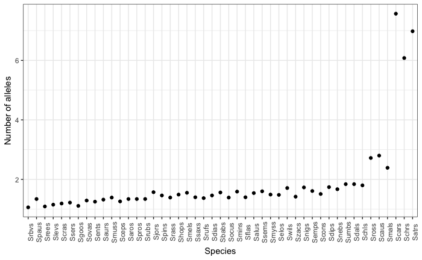

```r
toolkit$Population <- factor(toolkit$Population, levels = toolkit$Population[order(toolkit$Unbiased_Hz)])
# plot the number of alleles vs the species
toolkit_alleles <- toolkit %>%
  ggplot(aes(x = Population, y = No_Alleles)) +
  geom_point() +
  theme_bw()
toolkit_alleles +
  theme(
    axis.text.x = element_text(angle = 90)
  ) +
  xlab("Species") +
  ylab("Number of alleles")
```

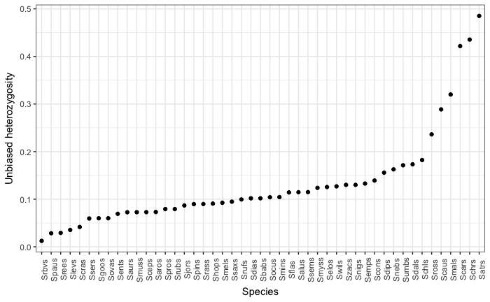

```r
hz_plot <- toolkit %>%
  ggplot(aes(x = Population, y = Unbiased_Hz)) +
  geom_point() +
  theme_bw()
hz_plot +
  theme(
    axis.text.x = element_text(angle = 90)
  ) +
  xlab("Species") +
  ylab("Unbiased heterozygosity")
```

What if I wanted to generate an estimate of overall allele frequencies per species from the baseline data?

| group | locus | indiv.ID | haplotype.1 | haplotype.2 |
| --- | --- | --- | --- | --- |
| Satrovirens | Plate_1_A01_Sat_GW603857_consensus | s1000 | ACTAGCGGT | ACTAGCGTT |
| Satrovirens | Plate_1_A11_Sat_GE820299_consensus | s1000 | CGGCTCCGGGTATCT | CGGCTCCGGGTATCT |
| Satrovirens | Plate_2_A09_Sat_EW986980_consensus | s1000 | CGAGACATAATTTGTT | CGAGACATCATCTGTT |
| Satrovirens | Plate_2_C08_Sat_EW987116_consensus | s1000 | AGACTTCGG | AGACTTCGG |
| Satrovirens | Plate_2_G06_Sat_EW987118_consensus | s1000 | AACATGGTCGTGCTACGG | AACATGGTCGTGCTACGG |
| Satrovirens | Plate_3_C03_Sat_GE798118_consensus | s1000 | TGAAGGGCGGTGCAGATACCAC | TGAAGGGCGGTGCAGATACCAC |
| Satrovirens | Plate_4_E10_Sat_EW976030_consensus | s1000 | AGCGCTGTGACTATT | AGCGCTGTGGCTACT |
| Satrovirens | Plate_4_G06_Sat_EW976181_consensus | s1000 | CACGTCGCGCCACTCCGGAGAGGC | CACGTCGTGCCACTCCGGAGAGGC |
| Satrovirens | tag_id_1049 | s1000 | AACCCAGCC | AACCCAGCC |
| Satrovirens | tag_id_108 | s1000 | ATCCATTAGGTTGTTCGCCGC | ATCCATTAGGTTGTTCGCCGC |

[output cut: 990 more lines]

For self-assignment results:

[figure not shown]

What I want is the proportion of samples that were correctly assigned (at any level)

```r
# total proportion
ref_self %>%
  filter(inferred_collection == collection) %>%
  filter(scaled_likelihood > 0.43) %>%
  group_by(indiv) %>%
  unique()
```

| indiv | collection | repunit | inferred_collection | inferred_repunit | scaled_likelihood | log_likelihood | z_score | n_non_miss_loci | n_miss_loci | missing_loci |
| --- | --- | --- | --- | --- | --- | --- | --- | --- | --- | --- |
| s679 | Salutus | Salutus | Salutus | Salutus | 1.0000000 | -27.5796321 | 1.183759e+00 | 83 | 7 |  |
| s680 | Salutus | Salutus | Salutus | Salutus | 1.0000000 | -28.9348670 | 9.468503e-01 | 82 | 8 |  |
| s681 | Salutus | Salutus | Salutus | Salutus | 1.0000000 | -51.2169498 | -2.275599e+00 | 83 | 7 |  |
| s691 | Salutus | Salutus | Salutus | Salutus | 1.0000000 | -37.7953537 | -2.132521e-01 | 84 | 6 |  |
| s692 | Salutus | Salutus | Salutus | Salutus | 1.0000000 | -32.2411127 | 4.538764e-01 | 82 | 8 |  |
| s693 | Salutus | Salutus | Salutus | Salutus | 1.0000000 | -39.1955210 | -5.162443e-01 | 83 | 7 |  |
| s702 | Salutus | Salutus | Salutus | Salutus | 1.0000000 | -28.3211692 | 8.542418e-01 | 82 | 8 |  |
| s703 | Salutus | Salutus | Salutus | Salutus | 1.0000000 | -23.2616838 | 1.067297e+00 | 80 | 10 |  |
| s704 | Salutus | Salutus | Salutus | Salutus | 1.0000000 | -49.8784710 | -1.981635e+00 | 84 | 6 |  |
| s714 | Salutus | Salutus | Salutus | Salutus | 1.0000000 | -29.7979883 | 2.170128e-03 | 79 | 11 |  |

[output cut: 990 more lines]

```r
ref_self %>%
  #filter(inferred_repunit == repunit) %>%
  filter(scaled_likelihood > 0.43) %>%
  filter(z_score > 3) # could make a note that the z_score is pretty tight (i.e. < 3)

# proportions?
collection <- ref_self %>%
  filter(scaled_likelihood > 0.43) %>%
  group_by(collection) %>%
  tally()

infer_col <- ref_self %>%
  filter(scaled_likelihood > 0.95) %>%
  group_by(inferred_collection) %>%
  tally()

pro_selfass <- collection %>%
  left_join(infer_col, by = c("collection" = "inferred_collection")) %>%
  mutate(prop = n.y / n.x) %>%
  ggplot(aes(x = collection, y = prop)) +
  geom_bar(stat = "identity") +
  theme_bw()

pro_selfass +
  theme(
    axis.text.x = element_text(angle = 90)
  ) +
  xlab("Species") +
  ylab("Proportion correctly assigned")
```

[output not shown]

```r
# Make a figure that shows for which colonies gsi assignment is effective
barplot <- ref_self %>%
  filter(scaled_likelihood > 0.43) %>%
  group_by(repunit) %>%
  mutate(result = ifelse(repunit == inferred_repunit, "yes", "no")) %>%
  count(result) %>% # what proportion of each colony was correctly or incorrectly assigned?
  mutate(prop = (n/sum(n))) %>%
  ggplot(aes(x = repunit, y = prop, fill = result)) +
  geom_bar(stat = "identity")

bp2 <- barplot + guides(fill=guide_legend(title="Correct assignment")) +
  xlab("Species") +
  ylab("Proportion") +
  theme_bw() +
  scale_fill_manual(values = c("red", "dark blue"))


bp2 +
  theme(
    axis.text.x = element_text(angle = 90)
  )

#ggsave("pdf_outputs/self_assignments_all_samples.pdf", height = 7, width = 10)
```

[output not shown]

That’s good, but maybe too simple. Let’s see if I can make a plot that also shows what proportion of each species was assigned to each other species.

```r
# Where does the incorrect proportion get assigned?
colplot <- ref_self %>%
  filter(scaled_likelihood > 0.95) %>%
  group_by(repunit, inferred_repunit) %>%
  mutate(result = ifelse(repunit == inferred_repunit, "yes", "no")) %>%
  count(result) %>% # what proportion of each species was correctly or incorrectly assigned?
  ungroup(inferred_repunit) %>%
  group_by(repunit) %>%
  mutate(prop = (n/sum(n))) %>%
  ggplot(aes(x = repunit, y = prop, fill = inferred_repunit)) +
  geom_bar(stat = "identity") +
  theme_bw()

colplot + guides(fill=guide_legend(title="Assigned species")) +
  xlab("Species") +
  ylab("Proportion") +
  theme(
    axis.text.x = element_text(angle = 90)
  )
```

[output not shown]

```r
# Make a figure that shows for which colonies gsi assignment is effective
bp_tot <- ref_self %>%
  filter(scaled_likelihood > 0.95) %>%
  group_by(repunit) %>%
  mutate(result = ifelse(repunit == inferred_repunit, "yes", "no")) %>%
  count(result) %>%
  left_join(., collection, by = c("repunit" = "collection")) %>%
  rename(tot_samples = n.y) %>%
  rename(samples = n.x) %>%
  mutate(prop = (samples / tot_samples)) %>%
  ggplot(aes(x = repunit, y = prop, fill = result)) +
  geom_bar(stat = "identity")

bp_tot2 <- bp_tot + guides(fill=guide_legend(title="Correct assignment")) +
  xlab("Species") +
  ylab("Proportion") +
  theme_bw() +
  scale_fill_manual(values = c("red", "dark blue"))


bp_tot2 +
  theme(
    axis.text.x = element_text(angle = 90)
  )

#ggsave("pdf_outputs/self_assignments_total.pdf", height = 7, width = 10)
```

[output not shown]